# Developmental curves

Michael Frank and Molly Lewis

Last updated on 2020-09-18.

# Introduction

Trying to pick back up the question of how different developmental phenomnena relate to one another and how they change over time.

Open questions:

1. is growth (in ES) logarithmic, exponential, linear, etc.?
2. are phenomena all growing from the same zero point or are there offsets (e.g., do somethings “start” later or does all learning start at birth)

Methodological idea: use bayesian meta-regression and model comparison to try and model ES across phenomena.

Confounds:

- selection of harder/easier studies across papers - need to look potentially at within-paper slopes
- method confounds - need to control for this
- need to remove MAs that don’t represent real phenomena - major judgment call here

Might want to limit to early language for now? Also could consider limiting to 0-36 or 0-48 months just because things blow up after that and data are sometimes sparse.

# Exploration

Get MA data from metalabr package. Filter to kids =<36 mo. Note that we’re currently missing 6 MAs.

```r
ml_dataset_info <- get_metalab_dataset_info() %>%
  filter(domain == "early_language")

ml_data <- get_metalab_data(ml_dataset_info) %>%
    filter(mean_age_months < 36) %>%
    mutate(d_se_calc = sqrt(d_var_calc)) %>%
    select(short_cite, short_name, d_calc, d_se_calc, d_var_calc, method, mean_age_months)
```

[output not shown]

Data with curves by phenomenon.

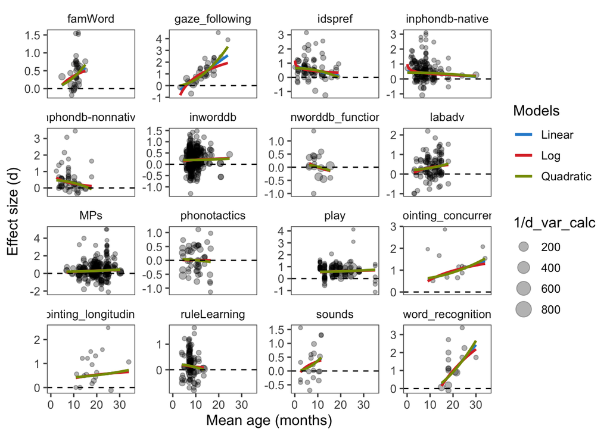

```r
ml_data %>%
  ggplot(aes(x = mean_age_months, y = d_calc,
             weight = 1/d_var_calc)) +
  geom_point(aes(size = 1/d_var_calc),
             alpha = .3) +
  geom_smooth(method="lm", formula = y ~ x,
              aes(col = "Linear"),
              se = FALSE) +
  geom_smooth(method="lm", formula = y ~ log(x),
              aes(col = "Log"),
              se = FALSE) +
  geom_smooth(method="lm", formula = y ~ I(x^2),
              aes(col = "Quadratic"),
              se = FALSE) +
  facet_wrap(~ short_name, scales = "free_y") +
  geom_hline(yintercept = 0, lty = 2, col = "black") +
  xlab("Mean age (months)") +
  ylab("Effect size (d)") +
  scale_colour_solarized(name="Models", breaks = c("Linear", "Log",
                                                "Quadratic", "Linear and Log"),
                                     labels=c("Linear" = "Linear",
                                              "Log" = "Log",
                                              "Quadratic" = "Quadratic",
                                              "Linear and Log" = "Linear and Log")) +
  theme_few()
```

# Bayesian MA on IDS preference

Note, pulling heavily from:

- https://solomonkurz.netlify.app/post/bayesian-meta-analysis/
- https://vuorre.netlify.app/post/2016/09/29/meta-analysis-is-a-special-case-of-bayesian-multilevel-modeling/

## Fit the Metafor version (multi-level)

```r
idspref <- ml_data %>%
  filter(short_name == "idspref")

idspref_metafor <- rma.mv(yi = d_calc, V = d_var_calc, data = idspref, random = ~ 1 | short_cite)
idspref_metafor
```

```
##
## Multivariate Meta-Analysis Model (k = 75; method: REML)
##
## Variance Components:
##
##             estim    sqrt  nlvls  fixed      factor
## sigma^2    0.2403  0.4902     23     no  short_cite
##
## Test for Heterogeneity:
## Q(df = 74) = 429.1827, p-val < .0001
##
## Model Results:
##
## estimate      se    zval    pval   ci.lb   ci.ub
##   0.6646  0.1092  6.0841  <.0001  0.4505  0.8786  ***
##
## ---
## Signif. codes:  0 '***' 0.001 '**' 0.01 '*' 0.05 '.' 0.1 ' ' 1
```

## Fit the Bayesian version - uninformative prior

```r
idspref_bayes_uninformative <-
  brm(data = idspref,
      family = gaussian,
      d_calc | se(d_se_calc) ~ 1 + (1 | short_cite),
            prior = c(prior(uniform(-5, 5), class = Intercept),
                    prior(uniform(-5, 5), class = sd)),
      iter = 2000, warmup = 1000, cores = 4, chains = 4,
      seed = 14)
```

[output not shown]

```r
idspref_bayes_uninformative
```

```
##  Family: gaussian
##   Links: mu = identity; sigma = identity
## Formula: d_calc | se(d_se_calc) ~ 1 + (1 | short_cite)
##    Data: idspref (Number of observations: 75)
## Samples: 3 chains, each with iter = 2000; warmup = 1000; thin = 1;
##          total post-warmup samples = 3000
##
## Group-Level Effects:
## ~short_cite (Number of levels: 23)
##               Estimate Est.Error l-95% CI u-95% CI Rhat Bulk_ESS Tail_ESS
## sd(Intercept)     0.52      0.10     0.35     0.75 1.00      658     1124
##
## Population-Level Effects:
##           Estimate Est.Error l-95% CI u-95% CI Rhat Bulk_ESS Tail_ESS
## Intercept     0.67      0.11     0.47     0.90 1.01      490      855
##
## Family Specific Parameters:
##       Estimate Est.Error l-95% CI u-95% CI Rhat Bulk_ESS Tail_ESS
## sigma     0.00      0.00     0.00     0.00 1.00     3000     3000
##
## Samples were drawn using sampling(NUTS). For each parameter, Bulk_ESS
## and Tail_ESS are effective sample size measures, and Rhat is the potential
## scale reduction factor on split chains (at convergence, Rhat = 1).
```

## Fit the Bayesian version - informative prior

```r
idspref_bayes <-
  brm(data = idspref,
      family = gaussian,
      d_calc | se(d_se_calc) ~ 1 + (1 | short_cite),
      prior = c(prior(normal(0, 1), class = Intercept),
                prior(cauchy(0, 1), class = sd)),
      iter = 2000, warmup = 1000, cores = 4, chains = 4,
      seed = 14)
```

[output not shown]

```r
idspref_bayes
```

```
##  Family: gaussian
##   Links: mu = identity; sigma = identity
## Formula: d_calc | se(d_se_calc) ~ 1 + (1 | short_cite)
##    Data: idspref (Number of observations: 75)
## Samples: 3 chains, each with iter = 2000; warmup = 1000; thin = 1;
##          total post-warmup samples = 3000
##
## Group-Level Effects:
## ~short_cite (Number of levels: 23)
##               Estimate Est.Error l-95% CI u-95% CI Rhat Bulk_ESS Tail_ESS
## sd(Intercept)     0.51      0.10     0.36     0.73 1.00      678     1168
##
## Population-Level Effects:
##           Estimate Est.Error l-95% CI u-95% CI Rhat Bulk_ESS Tail_ESS
## Intercept     0.65      0.11     0.44     0.87 1.01      611     1085
##
## Family Specific Parameters:
##       Estimate Est.Error l-95% CI u-95% CI Rhat Bulk_ESS Tail_ESS
## sigma     0.00      0.00     0.00     0.00 1.00     3000     3000
##
## Samples were drawn using sampling(NUTS). For each parameter, Bulk_ESS
## and Tail_ESS are effective sample size measures, and Rhat is the potential
## scale reduction factor on split chains (at convergence, Rhat = 1).
```

# All MAs

Bayesian models with all non-null MAs.

Get non-null MAs. Null MA defined as a case where CI includes 0.

[output not shown]

[output cut: 248 more lines]

[output not shown]

## Linear age predictor

ISSUES:

- should method be a random or fixed effect?
- this weird thing happens where every time I fit this model, the first 3 chains error out, and the 4th one works. The error is `[1] "Error in sampler$call_sampler(args_list[[i]]) : " [2] " c++ exception (unknown reason)"`
- the model you specified doesn’t have a prior for age…..do we need/want one? What happens if you don’t specify it? I added a normal prior.

```r
alldata_bayes_linear <- ml_data %>%
  filter(short_name %in% non_null_mas) %>%
  brm(data = .,
      family = gaussian,
      d_calc | se(d_se_calc) ~ mean_age_months
                                + method # should method be a random effect or a fixed effect?
                                + (mean_age_months | short_cite)
                                + (mean_age_months | short_name),
      prior = c(prior(normal(0, 1), class = Intercept),
               prior(normal(0, 1), class = b),
                prior(cauchy(0, 1), class = sd)),
      iter = 5000, warmup = 2000, cores = 4, chains = 4,
      seed = 14)
```

[output not shown]

`launch_shinystan(alldata_bayes)` launches a cool shiny app that allows you to explore the parameters interactively.

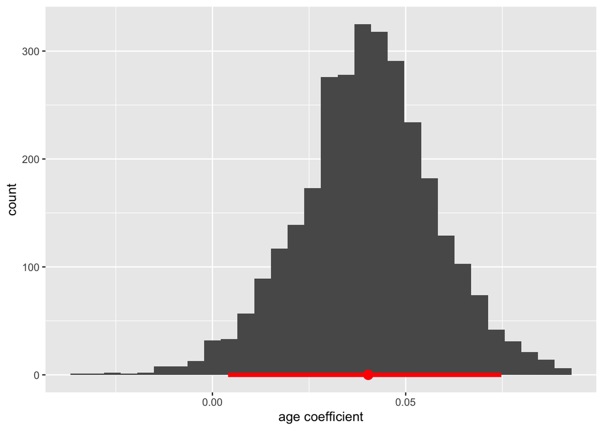

```r
alldata_bayes_linear %>%
  spread_draws(b_mean_age_months) %>%
  ggplot(aes(x = b_mean_age_months)) +
  geom_histogram() +
  geom_halfeyeh(.width = .95, size = 8, color = "red") +
  xlab("age coefficient")
```

## Log linear age predictor

Now, let’s do log age:

```r
alldata_bayes_log <- ml_data %>%
  filter(short_name %in% non_null_mas) %>%
  brm(data = .,
      family = gaussian,
      d_calc | se(d_se_calc) ~ log(mean_age_months)
                                + method # should method be a random effect or a fixed effect?
                                + (mean_age_months | short_cite)
                                + (mean_age_months | short_name),
      prior = c(prior(normal(0, 1), class = Intercept),
                prior(normal(0, 1), class = b),
                prior(cauchy(0, 1), class = sd)),
      iter = 5000, warmup = 2000, cores = 4, chains = 4,
      seed = 14)
```

```
## [[1]]
## Stan model 'b5d956ccf9461783f3d608a424340634' does not contain samples.
##
## [[2]]
## Stan model 'b5d956ccf9461783f3d608a424340634' does not contain samples.
##
## [[3]]
## Stan model 'b5d956ccf9461783f3d608a424340634' does not contain samples.
```

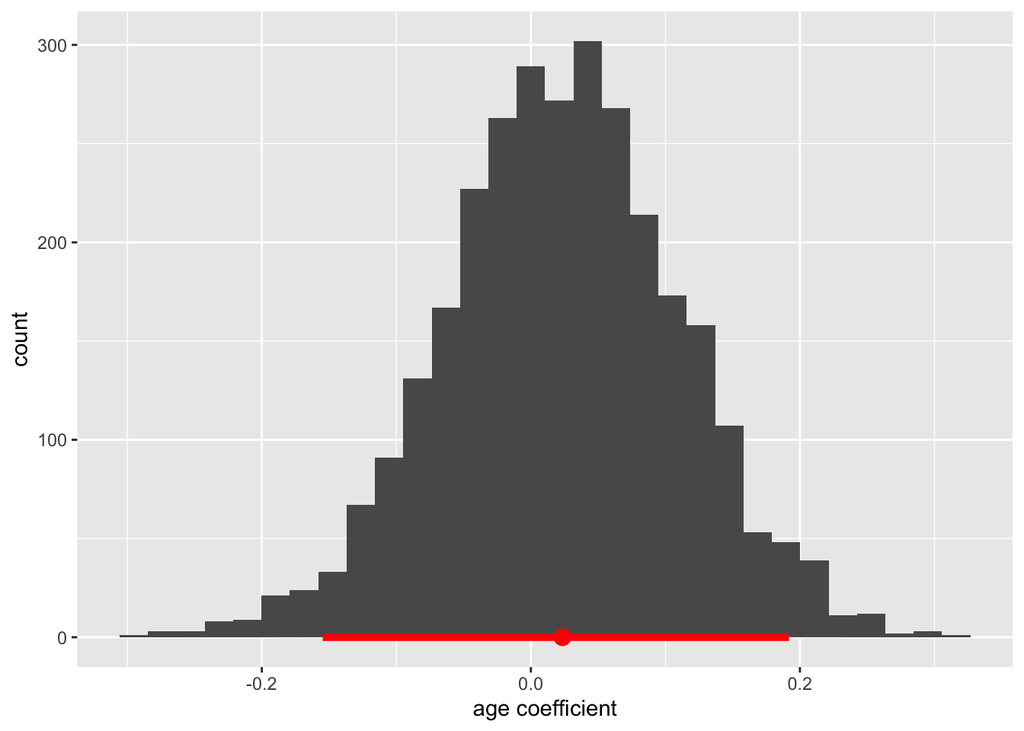

```r
alldata_bayes_log %>%
  spread_draws(b_logmean_age_months) %>%
  ggplot(aes(x = b_logmean_age_months)) +
  geom_histogram() +
  geom_halfeyeh(.width = .95, size = 8, color = "red") +
  xlab("age coefficient")
```

Compare these models via their R-squared values:

```r
bayes_R2(alldata_bayes_linear)
```

```
##     Estimate  Est.Error      Q2.5     Q97.5
## R2 0.3770386 0.01385712 0.3505682 0.4050078
```

```r
bayes_R2(alldata_bayes_log)
```

```
##    Estimate  Est.Error      Q2.5     Q97.5
## R2 0.375339 0.01377097 0.3481582 0.4020414
```